# Pravděpodobnost

## Proč ve statistice potřebujeme pravděpodobnost?

Klasická inferenční statistika funguje asi takto:

- udělám předpoklad o světě (vytvořím model světa)
- seberu data
- ptám se, jak překvapivá jsou tato data za předpokladu modelu
- pokud jsou velmi překvapivá (nepravděpodobná) odmítnu původní model

Teorie pravděpodobnosti nás učí formálně vyhodnocovat (ne)překvapivost pozorovaných dat.

## Motivační příklad

Existuje rozdíl ve výšce žen a mužů?

Model světa: neexistuje

Seberu data:

- ženy: 166, 175, 164, 171
- muži: 180, 172, 175, 186

Jaká je pravděpodobnost, že bychom dostali takto nebo více extrémní rozdíl mezi výškou žen a mužů, pokud by skutečný rozdíl v populaci byl 0?

## Motivační příklad - rozuzlení

Data:

- ženy: 166, 175, 164, 171
- muži: 180, 172, 175, 186

Pravděpodobnost (za určitých předpokladů):

```
## [1] 0.059
```

## Axiomy teorie pravděpodobnosti

## Axiomy teorie pravděpodobnosti

1. \(Pr(z) >= 0\), kde z značí nějakou událost
2. \(Pr(sample space) = 1\)
3. Pokud \(z_i\), …, \(z_k\) jsou vzájemně se vylučující jevy: \(Pr(z_i \cup ... \cup z_k) = Pr(z_i) + ... + Pr(z_k)\)

Z těchto axiomů lze odvodit další užitečná pravidla, například:

- Pravidlo doplňku: \(Pr(z) = 1 - Pr(!z)\), kde vykřičník značí negaci
- Mlutiplikační pravidlo: Pravděpodobnost, že najednou nastanou vzájemně nezávislé jevy, se rovná součinu jejich individuálních pravděpodobností

## Dva přístupy k pravděpodobnosti

- Analytický přístup
- Simulační přístup

## Funkce rozdělení pravděpodobnosti (Probability distribution functions)

## Funkce rozdělení pravděpodobnosti (Probability distribution functions)

Jsou dvě:

- Hustota pravděpodobnosti (probability density function, PDF)
- Kumulativní distribuce (cumulative distribution function, CDF)

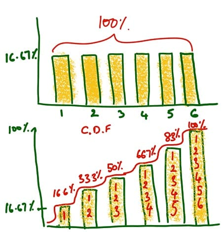

[Zdroj graduatetutor.com](https://www.graduatetutor.com/statistics-tutor/probability-density-function-pdf-and-cumulative-distribution-function-cdf/)

## Hustota pravděpodobnosti (probability density function, PDF)

Značení … budeme rozlišovat Pr ve smyslu pravděpodobnost, že proměnná bude nabývat určité hodnoty, a P ve smyslu funkce hustoty pravděpodobnosti pro celé spektrum možných hodnot proměnné.

\(P(y)\) … funkce hustoty pravděpodobnosti proměnné y

\(Pr(y=4)\) … pravděpodobnost, že na kostce padne 4

## Počítání pravděpodobnosti na základě PDF

- Hod kostkou, \(Pr(y = 3)\)?
- Hod kostkou, \(Pr(y != 3)\)?
- Hod kostkou, \(Pr(y >= 3)\)?
- Dva hody kostkou, \(Pr(y_1 >= 3 \;\&\; y_2 = 6)\)?

## Vybraná užitečná rozdělení pravděpodobnosti (užitečné modely světa)

## Ideální rozdělení č. 1: Rovnoměrné (uniformní)

- Všechny hodnoty mají stejnou pravděpodobnost výskytu
- Hod kostkou, tahání karty z balíčku, tahání tomboly … možná datum narození?

## Pravděpodobnost diskrétních a spojitých proměnných

- Pro diskrétní proměnné: PDF:

\[\sum_{for\;all\;y} P(y) = 1\]

\[ \int_{-\infty}^{+\infty} f(y) \, dy = 1\]

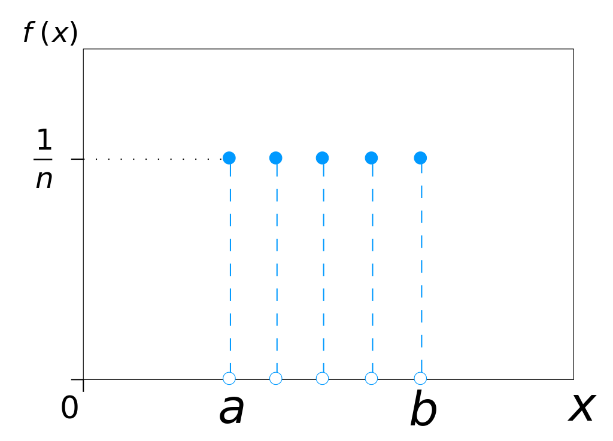

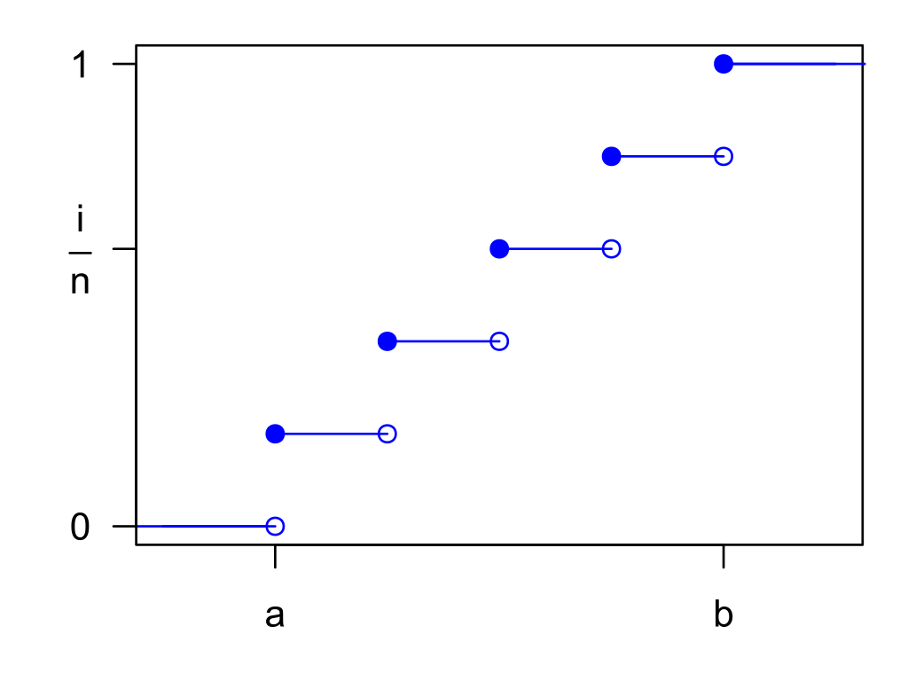

Diskrétní rovnoměrné

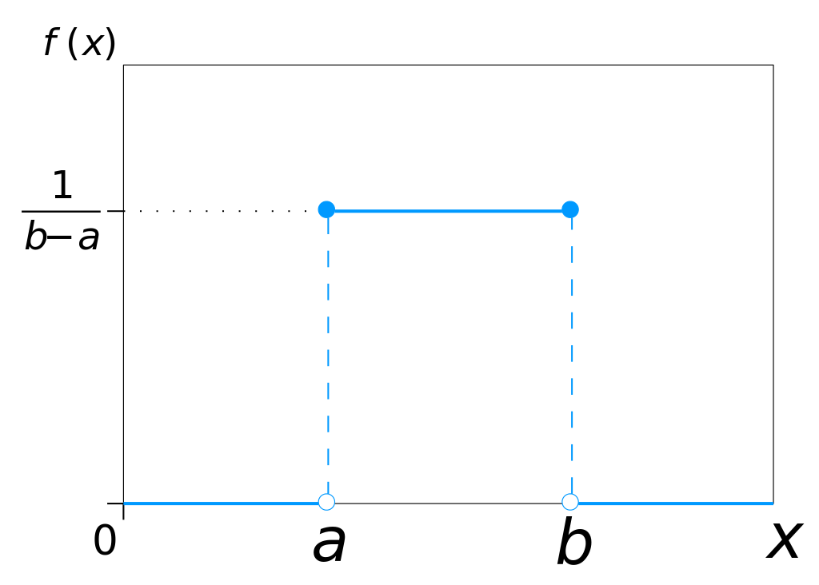

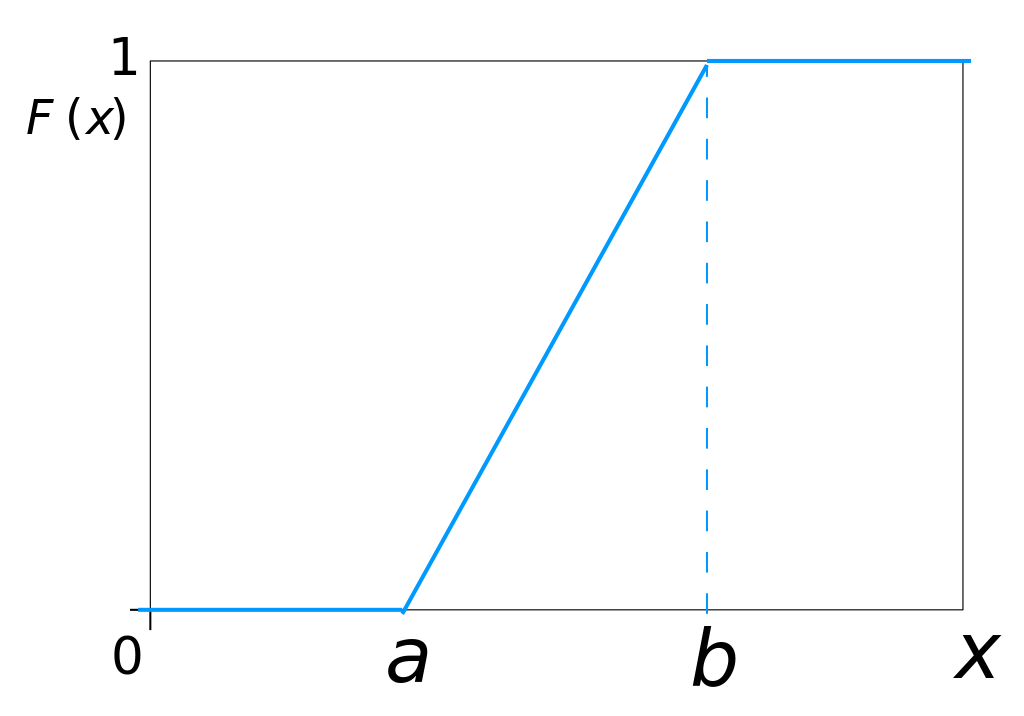

Spojité rovnoměrné

[Zdroj obrázků spojité](https://en.wikipedia.org/wiki/Continuous_uniform_distribution) a [Zdroj obrázků diskrétní](https://en.wikipedia.org/wiki/Discrete_uniform_distribution)

## Diskrétní rovnoměrné rozdělení - průměr a rozptyl

- a … minimum
- b … maximum
- n … počet možných hodnot

\[ Průměr = (a+b)/2 \]

\[ Rozptyl = (n^2 - 1)/12 \]

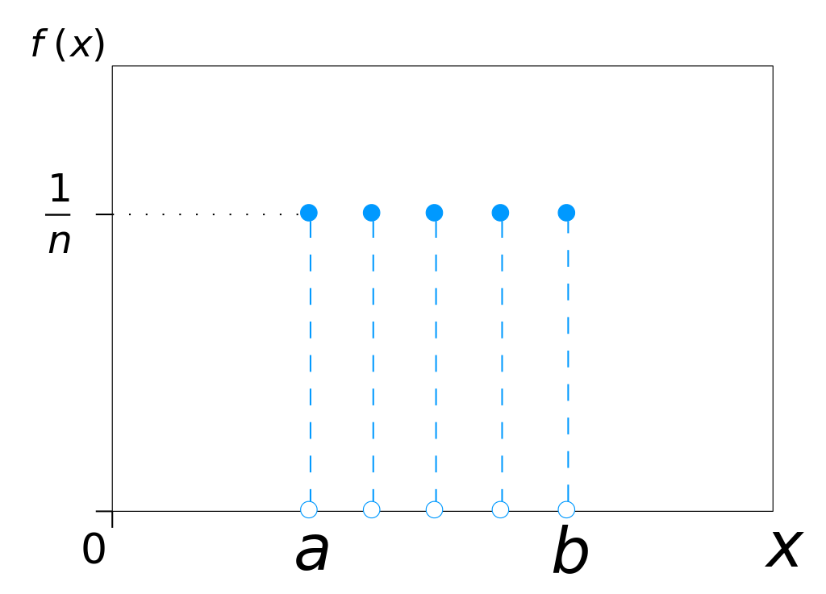

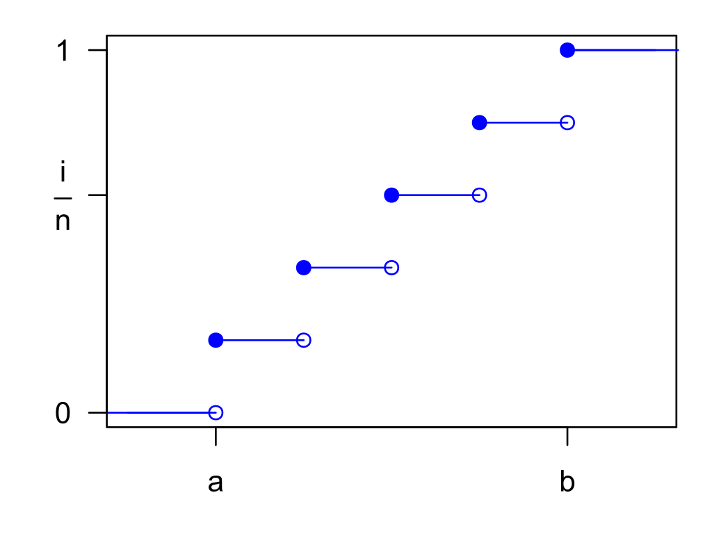

Diskrétní rovnoměrné

## Spojité rovnoměrné rozdělení - průměr a rozptyl, nadstavba

- a … minimum
- b … maximum

\[ Průměr = (a+b)/2 \]

\[ Rozptyl = (b - a)^2/12 \]

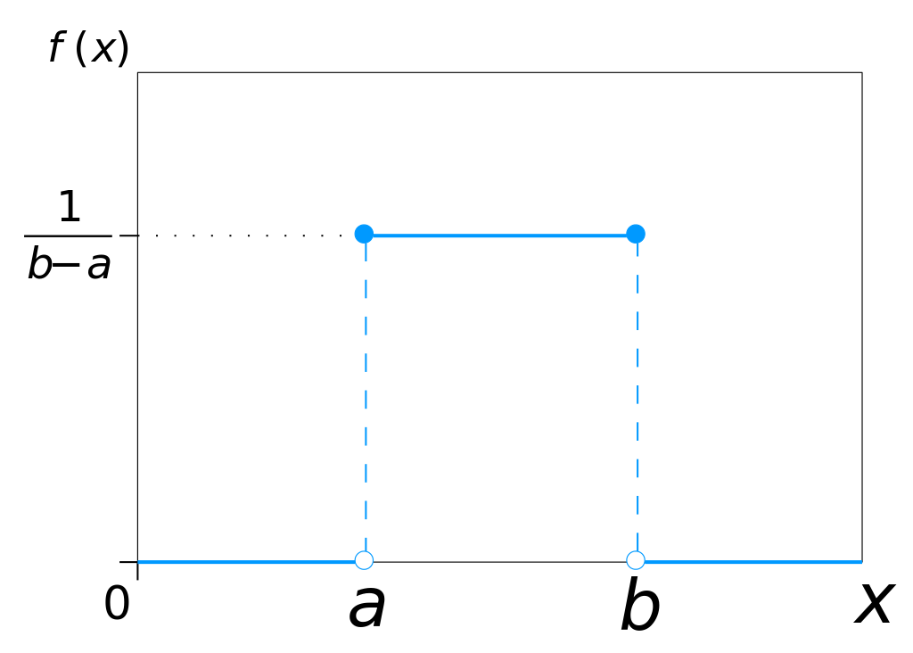

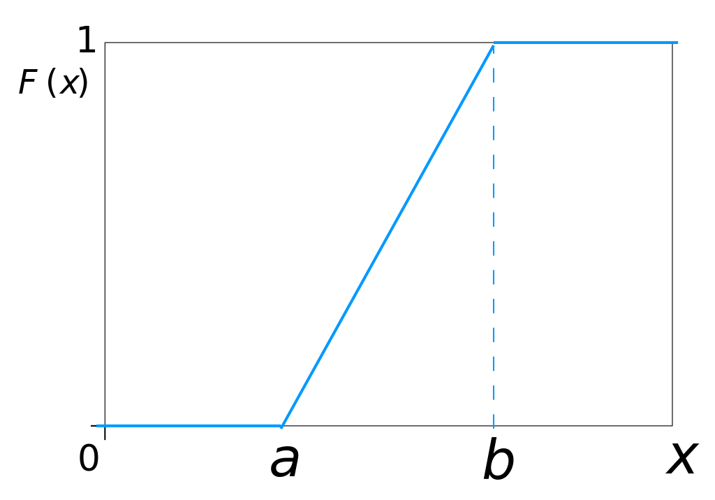

## Ideální rozdělení č. 2: Normální (Gaussovo)

- Tzv. zvonová křivka
- Střední a prostřední hodnoty jsou časté. Čím extrémnější hodnoty, tím méně časté
- Je na obrázku PDF, nebo CDF?

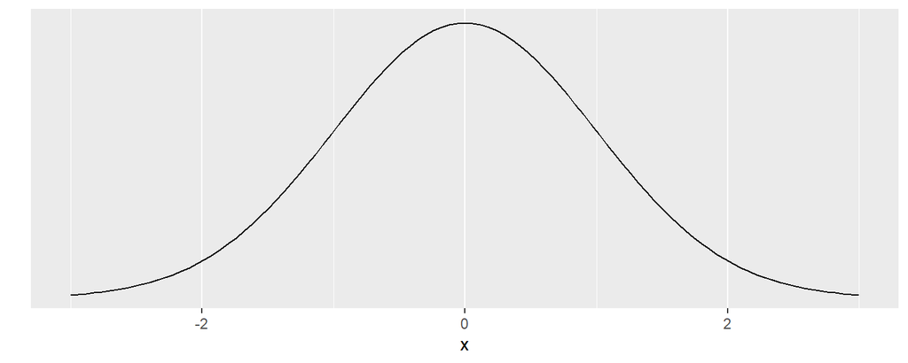

## Normální rozdělení: PDF a CDF

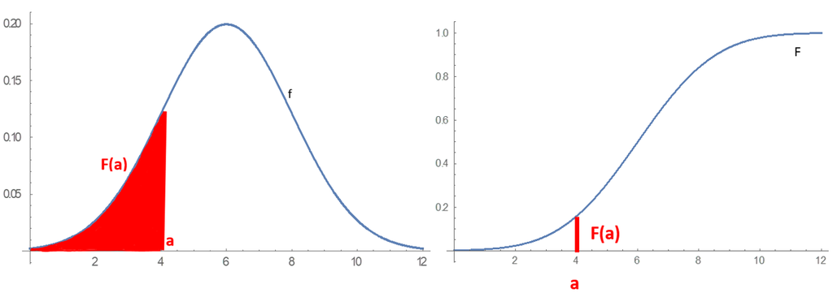

[Zdroj Wikipedie](https://en.wikipedia.org/wiki/Probability_distribution)

- Všimněte si: čím vyšší je PDF, tím strmější je CDF (obecná vlastnost funkcí rozdělení pravděpodobnosti, nejen pro normální rozdělení)

## Normální rozdělení - formální definice PDF (nadstavba)

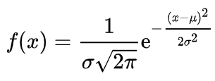

Vypadá to děsivě, ale pí a eulerovo číslo jsou konstanty, x zastuje hodnoty proměnné, takže jediné, co vám stačí, je \(\mu\) a \(\sigma\), tedy průměr a směrodatná odchylka.

Jinými slovy: normální rozdělení je plně efinováno dvěma parametry: průměrem a směrodatnou odchylkou.

## Standardní normální rozdělení a jeho vlastnosti

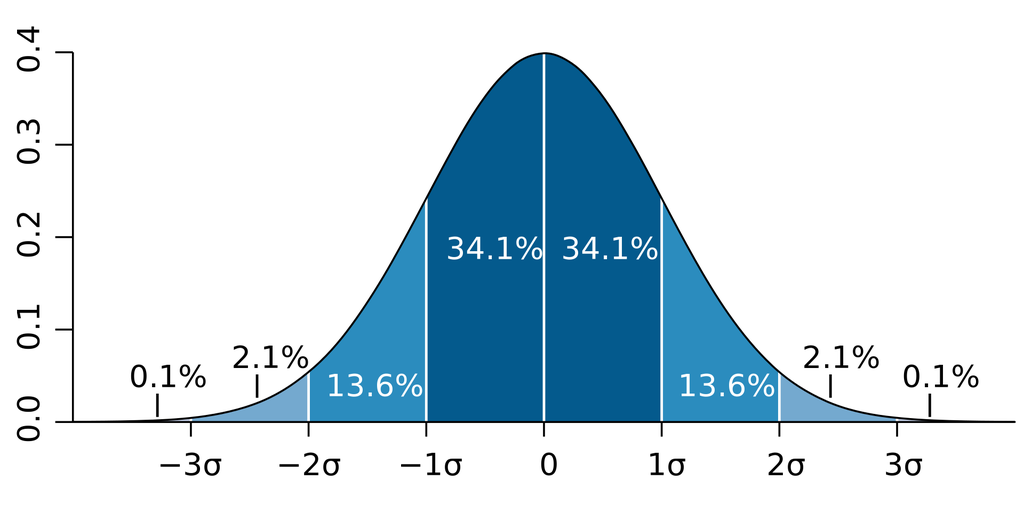

Zdroj [Wikipedia](https://en.wikipedia.org/wiki/Normal_distribution)

Pravidlo tří sigma (68-95-99,7)

## Různá normální rozdělení

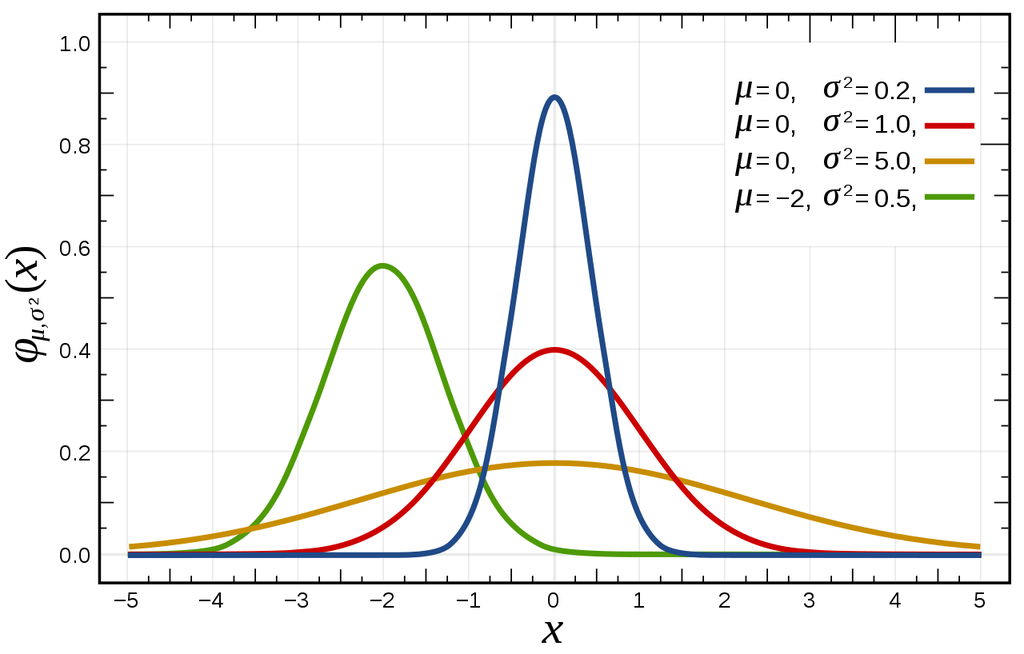

[Převzato z Wikipedie](https://cs.wikipedia.org/wiki/Norm%C3%A1ln%C3%AD_rozd%C4%9Blen%C3%AD#:~:text=Norm%C3%A1ln%C3%AD%20rozd%C4%9Blen%C3%AD%20neboli%20Gaussovo%20rozd%C4%9Blen%C3%AD,%2C%20p%C5%99edpisem%20nebo%20modelem%E2%80%9C.))

- Mezi jaké hodnoty spadá prostředních 68 % červeného rozdělení?
- Kolik procent pozorování červeného rozdělení spadá mezi hodnoty -2 a 1?
- Kolik procent pozorování červeného rozdělení spadá mezi hodnoty -3 a 0?

## Jak vzniká normální rozdělení? Vytvoření intuice

Typicky v důsledku mnoha malých vlivů. Působení těchto vlivů se častěji “vykrátí” (některé přidávají, jiné ubírají).

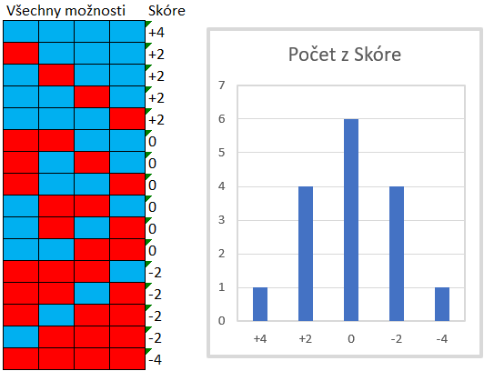

## Alternativní (Bernoulliho) rozdělení

- Rozdělení náhodné proměnné, která může nabývat pouze 1, nebo 0
- Pr(y=1) značíme \(p\)
- Pr(y=0) značíme \(1-p\) nebo \(q\)
- \(m = p\)
- \(var = p*q\)

Kontrolní otázky:

- Kolik vstupních údajů plně definuje alternativní rozdělení?
- Jak by vypadala funkce hustoty spojitého alternativního rozdělení?

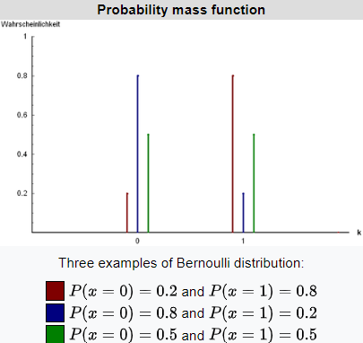

Zdroj [Wikipedia](https://en.wikipedia.org/wiki/Bernoulli_distribution)

## Binomické rozdělení (také Bernoulliho schéma)

- Popisuje výskyt jevu v \(n\) nezávislých pokusech, z nichž každý má stejnou pravděpodobnost úspěchu
- Plně definováno dvěma údaji:
  - \(n\), počet pokusů
  - \(p\), pravděpodobnost úspěchu
- \(m=np\)
- \(var=npq\)

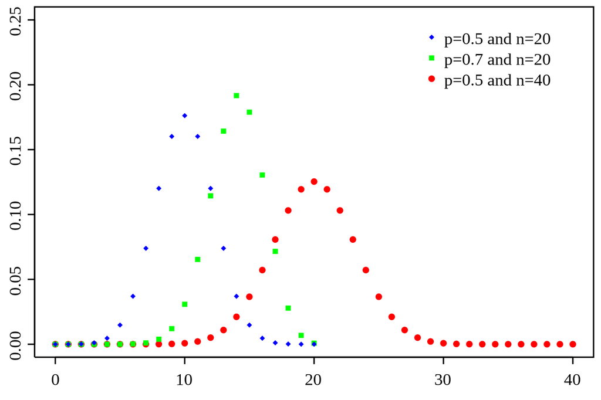

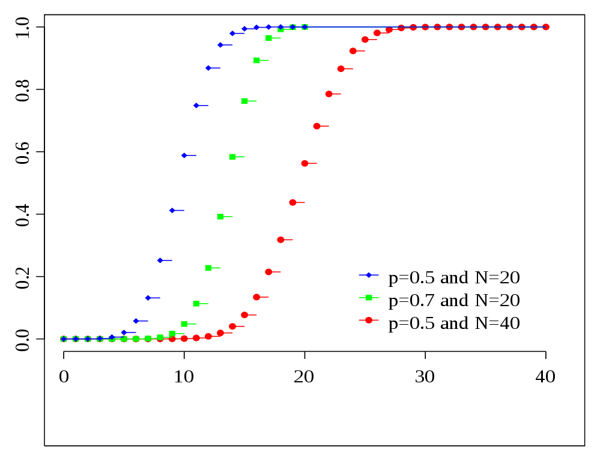

Zdroj [Wikipedia](https://en.wikipedia.org/wiki/Binomial_distribution#Bernoulli_distribution)

## Počítání s binomickým rozdělením

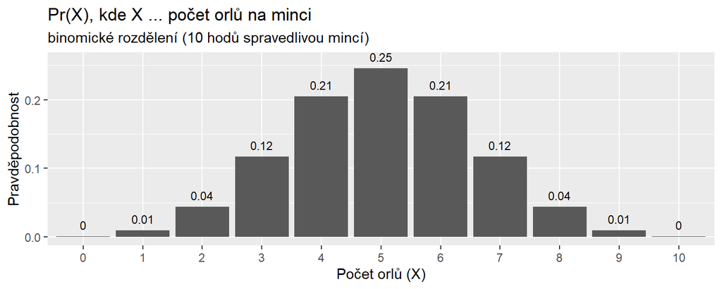

\[ P(k) = P(X = k) = {n \choose k} p^k(1-p)^{n-k} \]

kde:

\[ {n \choose k} = \frac{n!}{k!(n-k)!} \]

## Příklad: Přechod na trvalou hybridní výuku?

- X … proměnná, zda příznivec hybridní výuky (1), nebo ne (0)
- Pr(X=příznivec) = \(p_X\)
- Počet náhodně vybraných respondentů n = 10
- Y … počet příznivců v našem vzorku (teoreticky od 0 do 10)

Otázky:

- Jaké rozdělení má proměnná X? Co proměnná Y?
- Pr(Y=0), když \(p_X\) = 0.2
- Pr(Y=1), když \(p_X\) = 0.2
- Pr(Y>=2), když \(p_X\) = 0.2
- E(Y)?, když \(p_X\) = 0.2
- E(Y)?, když \(p_X\) = 0.5
- Var(Y)?, když \(p_X\) = 0.4
- Které stavy byste označili za běžné a které za extrémní?
- Pokud byste předpokládali \(p_X\) = 0.2, je 8 příznivců hybridní výuku extrémní stav, který by zpochybnil Vás předpoklad?
- Jak se výsledky změní, pokud n = 1000? Jak se změní tvar rozdělení?

## Změna tvaru binomického rozdělení při růstu \(n\)

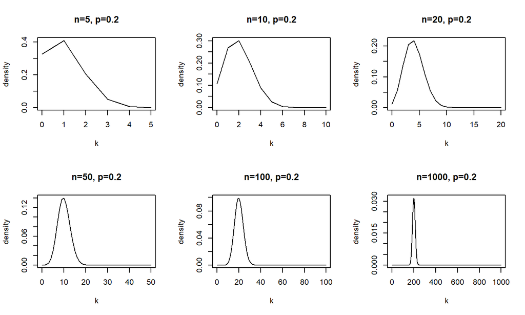

## Vyčíslení pravděpodobností v softwaru

Pravděpodobnost, že z 10 hodů mincí padne 4 nebo 5 orlů.

```r
sum(dbinom(4:5, 10, 0.5))
```

```
## [1] 0.4511719
```

Zkuste si doma ověřit výsledky pomocí funkce binom.dist v MS Excel.

## Proč se vůbec věnujeme teorii pravděpodobnosti?

## Proč ke statistice potřebujeme pravdědpodobnost?

Statistika nám pomáhá určit, jak (ne)pravděpodobná jsou určitá data za předpokladu určitého modelu.